# ggplot en trucks

Hier wat aanvullende trucks bij ggplot

Cédric Scherer, bewerking Harrie Jonkman true  
2022-06-28

```r
## pakketten
library(tidyverse)   ## datawetenschaps basispakket, collection waarin ook ggplot2 zit
library(systemfonts) ## om lettertypes te gebruiken
library(scico)       ## scico kleurpalletten (http://www.fabiocrameri.ch/colourmaps.php) in R
library(ggtext)      ## om in ggplot2 beter met tekst te kunnen werken
library(ggforce)     ## om missende functionaliteit aan ggplot2 toe te voegen
library(ggdist)      ## om onzekerheid te visualiseren in ggplot2
library(magick)      ## laden van plaatjes in R
library(patchwork)   ## om outputs van ggplot2 te combineren
```

## Inleiding

De afgelopen maand toch nog weer eens naar datavisualisatie gekeken en hoe je dat met R het beste kunt doen. Twee boeken nogeens gelezen hierover. Allereerst het boek van Rob Kabacoff [Data Visualization with R](https://rkabacoff.github.io/datavis/). Het is een handige introducte op `ggplot`en vooral een handige tutorial voor het visualiseren van data met R. Daarnaast het boek van Clause Wilke [Fundamentals of Data Visualization](https://clauswilke.com/dataviz/) dat meer een algemene reflectie is op data visualisatie. Het ga je op verschillende manieren van data naar visualisatie, wat zijn de onderliggende principes en waaraan moeten we bij datavisualisatie vooral denken. Toch heb ik de afgelopen maand vooral veel geleerd van Cédric Scherer. Ik zag dat hij op de conferentie van R binnenkort een inleiding geeft op het onderwerp datavisualisatie en zo zag ik via zijn Github site verschillend materiaal over datavisualisatie. Mooie en duidelijke inleidingen en twee ervan heb ik in het Nederlands overgezet. Hier een aandere inleiding op `ggplot`. [ggplot Wizardly](https://www.cedricscherer.com/slides/useR-2021_ggplot-wizardry-extended.pdf), met wat tips en trucks om mooie plots in R te maken.

## Data

```r
penguins <-
  readr::read_csv('https://raw.githubusercontent.com/rfordatascience/tidytuesday/master/data/2020/2020-07-28/penguins.csv') %>%
  ## om de namen van de soorten goed te spellen
  mutate(species = if_else(species == "Adelie", "Adélie", species)) %>%
  ## missende observaties weghalen
  filter(!is.na(bill_length_mm), !is.na(bill_depth_mm))

## inspecteren van de data
penguins
```

```
# A tibble: 342 x 8
   species island    bill_length_mm bill_depth_mm flipper_length_mm
   <chr>   <chr>              <dbl>         <dbl>             <dbl>
 1 Adélie  Torgersen           39.1          18.7               181
 2 Adélie  Torgersen           39.5          17.4               186
 3 Adélie  Torgersen           40.3          18                 195
 4 Adélie  Torgersen           36.7          19.3               193
 5 Adélie  Torgersen           39.3          20.6               190
 6 Adélie  Torgersen           38.9          17.8               181
 7 Adélie  Torgersen           39.2          19.6               195
 8 Adélie  Torgersen           34.1          18.1               193
 9 Adélie  Torgersen           42            20.2               190
10 Adélie  Torgersen           37.8          17.1               186
# ... with 332 more rows, and 3 more variables: body_mass_g <dbl>,
#   sex <chr>, year <dbl>
```

```r
##  Tabel tonen
View(penguins)

## als je een nette tabel in jouw rapport wilt opnemen
penguins %>%
  kableExtra::kbl() %>%
  kableExtra::kable_paper(full_width = TRUE) %>%
  kableExtra::kable_styling(bootstrap_options = c("striped", "condensed", "responsive")) %>%
  kableExtra::scroll_box(width = "700px", height = "500px")
```

| species | island | bill_length_mm | bill_depth_mm | flipper_length_mm | body_mass_g | sex | year |
| --- | --- | --- | --- | --- | --- | --- | --- |
| Adélie | Torgersen | 39.1 | 18.7 | 181 | 3750 | male | 2007 |
| Adélie | Torgersen | 39.5 | 17.4 | 186 | 3800 | female | 2007 |
| Adélie | Torgersen | 40.3 | 18.0 | 195 | 3250 | female | 2007 |
| Adélie | Torgersen | 36.7 | 19.3 | 193 | 3450 | female | 2007 |
| Adélie | Torgersen | 39.3 | 20.6 | 190 | 3650 | male | 2007 |
| Adélie | Torgersen | 38.9 | 17.8 | 181 | 3625 | female | 2007 |
| Adélie | Torgersen | 39.2 | 19.6 | 195 | 4675 | male | 2007 |
| Adélie | Torgersen | 34.1 | 18.1 | 193 | 3475 | NA | 2007 |
| Adélie | Torgersen | 42.0 | 20.2 | 190 | 4250 | NA | 2007 |
| Adélie | Torgersen | 37.8 | 17.1 | 186 | 3300 | NA | 2007 |
| Adélie | Torgersen | 37.8 | 17.3 | 180 | 3700 | NA | 2007 |
| Adélie | Torgersen | 41.1 | 17.6 | 182 | 3200 | female | 2007 |
| Adélie | Torgersen | 38.6 | 21.2 | 191 | 3800 | male | 2007 |
| Adélie | Torgersen | 34.6 | 21.1 | 198 | 4400 | male | 2007 |
| Adélie | Torgersen | 36.6 | 17.8 | 185 | 3700 | female | 2007 |
| Adélie | Torgersen | 38.7 | 19.0 | 195 | 3450 | female | 2007 |
| Adélie | Torgersen | 42.5 | 20.7 | 197 | 4500 | male | 2007 |
| Adélie | Torgersen | 34.4 | 18.4 | 184 | 3325 | female | 2007 |
| Adélie | Torgersen | 46.0 | 21.5 | 194 | 4200 | male | 2007 |
| Adélie | Biscoe | 37.8 | 18.3 | 174 | 3400 | female | 2007 |
| Adélie | Biscoe | 37.7 | 18.7 | 180 | 3600 | male | 2007 |
| Adélie | Biscoe | 35.9 | 19.2 | 189 | 3800 | female | 2007 |
| Adélie | Biscoe | 38.2 | 18.1 | 185 | 3950 | male | 2007 |
| Adélie | Biscoe | 38.8 | 17.2 | 180 | 3800 | male | 2007 |
| Adélie | Biscoe | 35.3 | 18.9 | 187 | 3800 | female | 2007 |
| Adélie | Biscoe | 40.6 | 18.6 | 183 | 3550 | male | 2007 |
| Adélie | Biscoe | 40.5 | 17.9 | 187 | 3200 | female | 2007 |
| Adélie | Biscoe | 37.9 | 18.6 | 172 | 3150 | female | 2007 |
| Adélie | Biscoe | 40.5 | 18.9 | 180 | 3950 | male | 2007 |
| Adélie | Dream | 39.5 | 16.7 | 178 | 3250 | female | 2007 |

[output cut: 312 more lines]

## Basis Plot

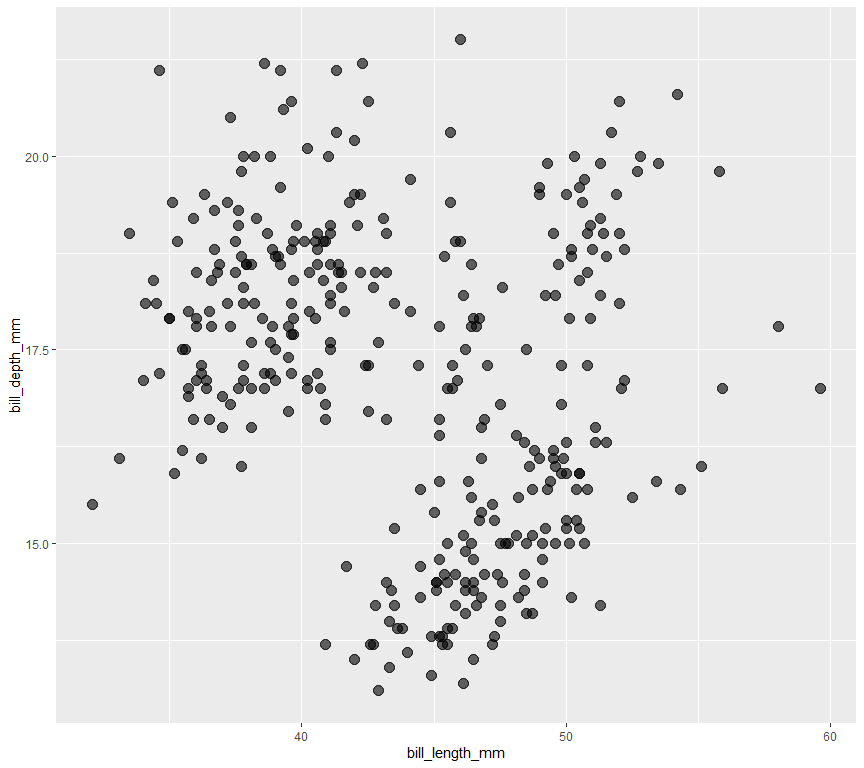

```r
## Eenvoudige plot: data + mappings + geometry
ggplot(penguins, aes(x = bill_length_mm, y = bill_depth_mm)) +
  geom_point(alpha = .6, size = 3.5)
```

```r
ggsave("00_scatterplot_raw.pdf", width = 9, height = 8, device = cairo_pdf)
```

## Aangepaste Plot

```r
## pas de themasettings aan (geldt voor alle plots die nog volgen)
theme_set(theme_minimal(base_size = 12, base_family = "Open Sans"))

## pas elementen algemeen aan (geldt voor alle plots die nog volgen)
theme_update(
  axis.ticks = element_line(color = "grey92"),
  axis.ticks.length = unit(.5, "lines"),
  panel.grid.minor = element_blank(),
  legend.title = element_text(size = 12),
  legend.text = element_text(color = "grey30"),
  plot.title = element_text(size = 18, face = "bold"),
  plot.subtitle = element_text(size = 12, color = "grey30"),
  plot.caption = element_text(size = 9, margin = margin(t = 15))
)
```

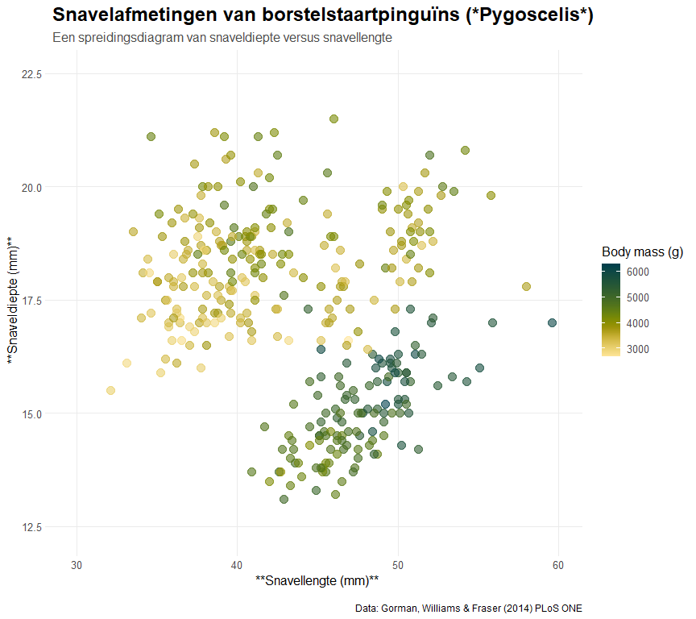

```r
ggplot(penguins, aes(x = bill_length_mm, y = bill_depth_mm)) +
  geom_point(aes(color = body_mass_g), alpha = .6, size = 3.5) +
  ## asschalen aanpassen
  scale_x_continuous(breaks = 3:6 * 10, limits = c(30, 60)) +
  scale_y_continuous(breaks = seq(12.5, 22.5, by = 2.5), limits = c(12.5, 22.5)) +
  ## kleuren aanpassen
  scico::scale_color_scico(palette = "bamako", direction = -1) +
  ## labels aanpassen
  labs(
    title = 'Snavelafmetingen van borstelstaartpinguïns (*Pygoscelis*)',
    subtitle = 'Een spreidingsdiagram van snaveldiepte versus snavellengte',
    caption = 'Data: Gorman, Williams & Fraser (2014) PLoS ONE',
    x = '**Snavellengte (mm)**',
    y = '**Snaveldiepte (mm)**',
    color = 'Body mass (g)'
  )
```

```r
ggsave("01_theme_color_labs.pdf", width = 9, height = 8, device = cairo_pdf)
```

## `{ggtext}`

> Het `ggtext` pakket biedt eenvoudige Markdown en HTML rendering voor ggplot2. Onder de motorkap gebruikt het pakket het `gridtext` pakket voor de eigenlijke rendering, en bijgevolg is het beperkt tot de mogelijkheden van `gridtext`. Er is ondersteuning voor Markdown in zowel thema-elementen (plot titels, ondertitels, bijschriften, aslabels, legenda’s, etc.) als in geoms (vergelijkbaar met `geom_text()`). In beide gevallen zijn er twee alternatieven, een voor het maken van eenvoudige tekstlabels en een voor het maken van tekstkaders met woordomloop.

→ www.wilkelab.org/ggtext

### `element_markdown()`

`element_markdown()` → geformateerde tekst elementen, b.v. titels, onderschrift, as-tekst, strooktekst

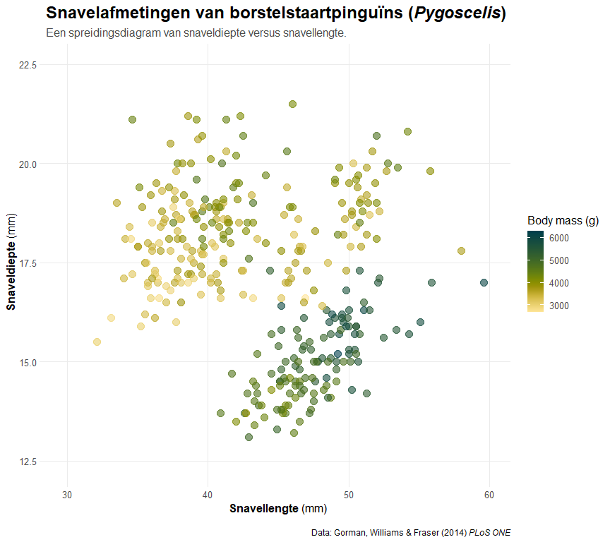

```r
## plot toewijzen aan `g` - we kunnen later nieuwe dingen aan deze plot toevoegen
## (tussen haakjes zodat het in één stap wordt toegewezen en uitgezet)
(gt <- ggplot(penguins, aes(x = bill_length_mm, y = bill_depth_mm)) +
  geom_point(aes(color = body_mass_g), alpha = .6, size = 3.5) +
  scale_x_continuous(breaks = 3:6 * 10, limits = c(30, 60)) +
  scale_y_continuous(breaks = seq(12.5, 22.5, by = 2.5), limits = c(12.5, 22.5)) +
  scico::scale_color_scico(palette = "bamako", direction = -1) +
  ## markdown opmaak met sterretjes
  labs(
    title = 'Snavelafmetingen van borstelstaartpinguïns (*Pygoscelis*)',
    subtitle = 'Een spreidingsdiagram van snaveldiepte versus snavellengte.',
    caption = 'Data: Gorman, Williams & Fraser (2014) *PLoS ONE*',
    x = '**Snavellengte** (mm)',
    y = '**Snaveldiepte** (mm)',
    color = 'Body mass (g)'
  ) +
  ## render respectievelijke tekstelementen
  theme(
    plot.title = ggtext::element_markdown(),
    plot.caption = ggtext::element_markdown(),
    axis.title.x = ggtext::element_markdown(),
    axis.title.y = ggtext::element_markdown()
  )
)
```

```r
ggsave("02a_ggtext_element_markdown.pdf", width = 9, height = 8, device = cairo_pdf)
```

### `element_markdown()` in combinatie met HTML

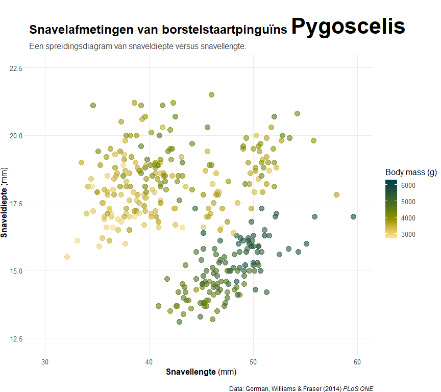

```r
## Gebruik HTML syntax om de tekstkleur te veranderen
gt_mar <- gt +
  labs(title = 'Snavelafmetingen van borstelstaartpinguïns <i style="color:#28A87D;">Pygoscelis</i>') +
  theme(plot.margin = margin(t = 25))

ggsave("02b_ggtext_element_markdown_color.pdf", width = 9, height = 8, device = cairo_pdf)

## Gebruik HTML syntax om het font te veranderen en de tekstgrootte
## fontaanpassingen werken nog niet in Windows
gt_mar +
  labs(title = 'Snavelafmetingen van borstelstaartpinguïns <b style="font-size:32pt;font-family:blacksword;">Pygoscelis</b>')
```

```r
ggsave("02c_ggtext_element_markdown_font.pdf", width = 9, height = 8, device = cairo_pdf)

## Onderstaande werkte bij mij niet
## Gebruik HTML syntax om plaatjes aan de tekstelementen toe te voegen
#gt_mar +
  #labs(title = 'Bill Dimensions of Brush-Tailed Penguins <img src="https://www.researchgate.net/profile/Jean_Lightner/publication/274710342/figure/fig8/AS:614338578640906@1523481139381/Pygoscelis-papua-Source-Wikipedia-http-wwwenwikipediaorg.png"‚ width="100"/>') +
  ## title with missing quotation mark to make an erroneous pdf -
  ## otherwise it throws an error because of RCurl on Windows OS
#  labs(title = 'Bill Dimensions of Brush-Tailed Penguins <img src="https://www.researchgate.net/profile/Jean_Lightner/publication/274710342/figure/fig8/AS:614338578640906@1523481139381/Pygoscelis-papua-Source-Wikipedia-http-wwwenwikipediaorg.png‚ width="100"/>') +

#ggsave("02d_ggtext_element_markdown_image.pdf", width = 9, height = 8, device = cairo_pdf)
```

### `element_textbox()`, `geom_richtext()` and `geom_textbox()`

`geom_richtext()` → geformateerde tekst labels met 360° rotatie

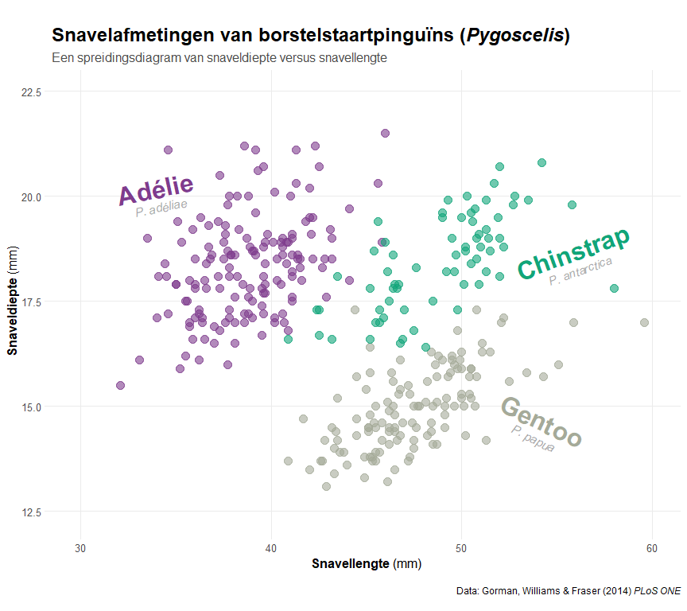

```r
gt_rich <- ggplot(penguins, aes(x = bill_length_mm, y = bill_depth_mm)) +
  geom_point(aes(color = species), alpha = .6, size = 3.5) +
  ## voeg tekstannotaties toe aan elk soort
  ggtext::geom_richtext(
    data = tibble(
      x = c(34, 56, 54), y = c(20, 18.5, 14.5),
      species = c("Adélie", "Chinstrap", "Gentoo"),
      lab = c("<b style='font-family:anton;font-size:24pt;'>Adélie</b><br><i style='color:darkgrey;'>P. adéliae</i>",
              "<b style='font-family:anton;font-size:24pt;'>Chinstrap</b><br><i style='color:darkgrey;'>P. antarctica</i>",
              "<b style='font-family:anton;font-size:24pt;'>Gentoo</b><br><i style='color:darkgrey;'>P. papua</i>"),
      angle = c(12, 20, 335)
    ),
    aes(x, y, label = lab, color = species, angle = angle),
    size = 4, fill = NA, label.color = NA,
    lineheight = .3
  ) +
  scale_x_continuous(breaks = 3:6 * 10, limits = c(30, 60)) +
  scale_y_continuous(breaks = seq(12.5, 22.5, by = 2.5), limits = c(12.5, 22.5)) +
  rcartocolor::scale_color_carto_d(palette = "Bold", guide = "none") +
  labs(
    title = 'Snavelafmetingen van borstelstaartpinguïns (*Pygoscelis*)',
    subtitle = 'Een spreidingsdiagram van snaveldiepte versus snavellengte',
    caption = 'Data: Gorman, Williams & Fraser (2014) *PLoS ONE*',
    x = '**Snavellengte** (mm)',
    y = '**Snaveldiepte** (mm)',
    color = 'Body mass (g)'
  )

(gt_rich +
  theme(
    plot.title = ggtext::element_markdown(),
    plot.caption = ggtext::element_markdown(),
    axis.title.x = ggtext::element_markdown(),
    axis.title.y = ggtext::element_markdown(),
    plot.margin = margin(25, 6, 15, 6)
  )
)
```

```r
ggsave("02e_ggtext_geom_richtext.pdf", width = 9, height = 8, device = cairo_pdf)
```

`element_textbox()` and `element_textbox_simple()` → formatted text boxes with word wrapping

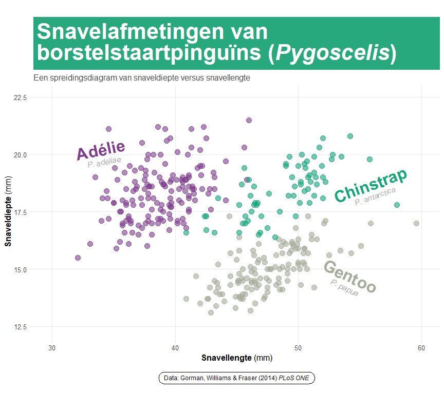

```r
(gt_box <- gt_rich +
  theme(
    ## zet titel in gevulde tekstblok
    plot.title = ggtext::element_textbox_simple(
      color = "white", fill = "#28A87D",  size = 32,
      padding = margin(8, 4, 8, 4), margin = margin(b = 5), lineheight= .9
    ),
    ## voeg ronde outline toe aan het onderschrift
    plot.caption = ggtext::element_textbox_simple(
      width = NULL, linetype = 1, padding = margin(4, 8, 4, 8),
      margin = margin(t = 15), r = grid::unit(8, "pt")
    ),
    axis.title.x = ggtext::element_markdown(),
    axis.title.y = ggtext::element_markdown(),
    plot.margin = margin(25, 6, 15, 6)
  )
)
```

```r
ggsave("02f_ggtext_element_textbox.pdf", width = 9, height = 8, device = cairo_pdf)
```

`geom_textbox()` → gevulde tekstblokken waar je woorden inzet

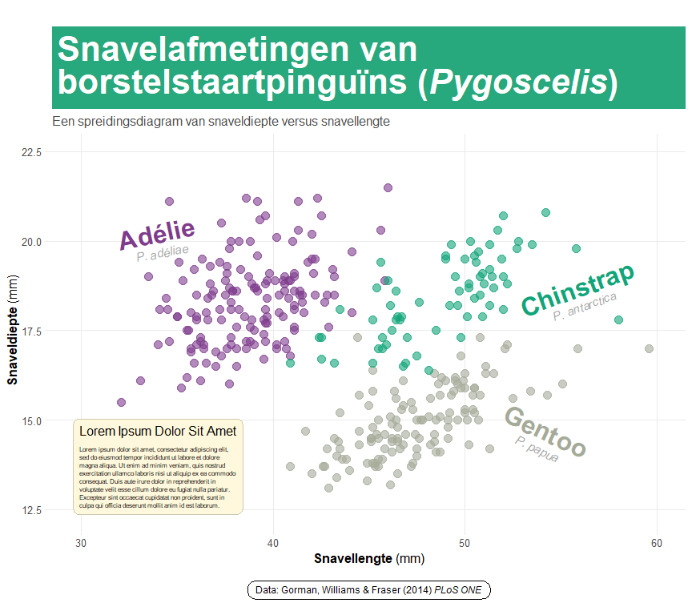

```r
gt_box +
  ## voeg tekstblok toe met lange paragraaf
  ggtext::geom_textbox(
    data = tibble(x = 34, y = 13.7, label = "<span style='font-size:12pt;font-family:anton;'>Lorem Ipsum Dolor Sit Amet</span><br><br>Lorem ipsum dolor sit amet, consectetur adipiscing elit, sed do eiusmod tempor incididunt ut labore et dolore magna aliqua. Ut enim ad minim veniam, quis nostrud exercitation ullamco laboris nisi ut aliquip ex ea commodo consequat. Duis aute irure dolor in reprehenderit in voluptate velit esse cillum dolore eu fugiat nulla pariatur. Excepteur sint occaecat cupidatat non proident, sunt in culpa qui officia deserunt mollit anim id est laborum."),
    aes(x, y, label = label),
    size = 2.2, family = "Open Sans",
    fill = "cornsilk", box.color = "cornsilk3",
    width = unit(11, "lines")
  ) +
  coord_cartesian(clip = "off")
```

```r
ggsave("02g_ggtext_geom_textbox.pdf", width = 9, height = 8, device = cairo_pdf)
```

```r
## gebruik ggtext-rendering voor de volgende grafieken
theme_update(
  plot.title = ggtext::element_markdown(),
  plot.caption = ggtext::element_markdown(),
  axis.title.x = ggtext::element_markdown(),
  axis.title.y = ggtext::element_markdown()
)
```

## `{ggforce}`

> `ggforce` is een pakket gericht op het leveren van ontbrekende functionaliteit aan `ggplot2` via het uitbreidingssysteem dat is geïntroduceerd met `ggplot2` v2.0.0. In het algemeen is `ggplot2` vooral gericht op exploratieve datavisualisatie om de gegevens te onderzoeken en minder op het leveren van hulpprogramma’s voor het samenstellen van aangepaste plots a la `D3.js`. `ggforce` is vooral een poging om deze “tekortkomingen” (ontwerpkeuzes is misschien een betere omschrijving) aan te pakken. Het doel is om een repository van geoms, stats, etc. aan te bieden die net zo goed gedocumenteerd en geïmplementeerd zijn als de officiële in `ggplot2`.

→ www.ggforce.data-imaginist.com

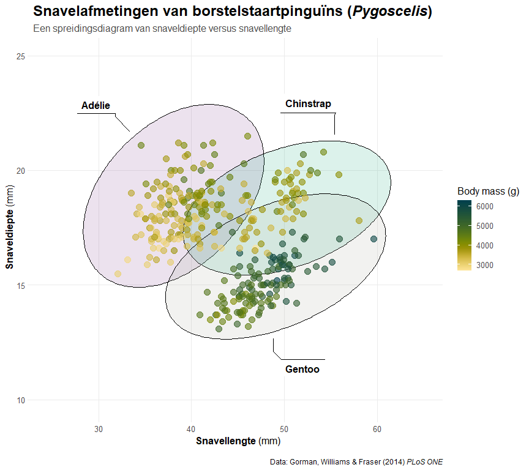

```r
## Grafiek die geannoteerd wordt met ggforce achteraf
gf <- ggplot(penguins, aes(x = bill_length_mm, y = bill_depth_mm)) +
  scico::scale_color_scico(palette = "bamako", direction = -1) +
  coord_cartesian(xlim = c(25, 65), ylim = c(10, 25)) +
  rcartocolor::scale_fill_carto_d(palette = "Bold") +
  labs(
    title = "Snavelafmetingen van borstelstaartpinguïns (*Pygoscelis*)",
    subtitle = 'Een spreidingsdiagram van snaveldiepte versus snavellengte',
    caption = "Data: Gorman, Williams & Fraser (2014) *PLoS ONE*",
    x = "**Snavellengte** (mm)",
    y = "**Snaveldiepte** (mm)",
    color = "Body mass (g)",
    fill = "Species"
  )

## ellipsen voor alle groepen
(gf +
  ggforce::geom_mark_ellipse(
    aes(fill = species, label = species),
    alpha = .15, show.legend = FALSE
  ) +
  geom_point(aes(color = body_mass_g), alpha = .6, size = 3.5)
)
```

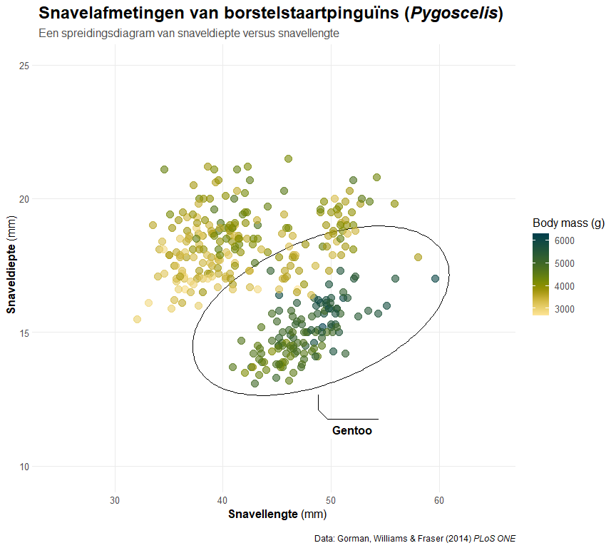

```r
ggsave("03a_ggforce_geom_mark_ellipsoid.pdf", width = 9, height = 8, device = cairo_pdf)

## ellipsen voor specifieke subset
(gf +
  ggforce::geom_mark_ellipse(
    aes(fill = species, label = species, filter = species == 'Gentoo'),
    alpha = 0, show.legend = FALSE
  ) +
  geom_point(aes(color = body_mass_g), alpha = .6, size = 3.5) +
  coord_cartesian(xlim = c(25, 65), ylim = c(10, 25))
)
```

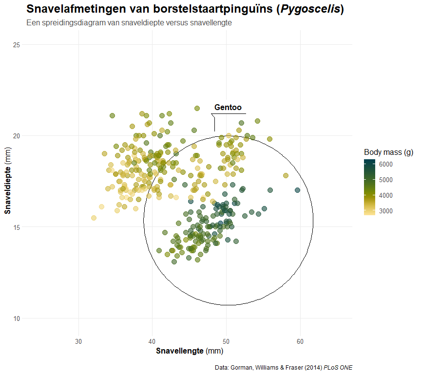

```r
ggsave("03b_ggforce_geom_mark_filtered.pdf", width = 9, height = 8, device = cairo_pdf)

## cirkels
(gf +
  ggforce::geom_mark_circle(
    aes(fill = species, label = species, filter = species == 'Gentoo'),
    alpha = 0, show.legend = FALSE
  ) +
  geom_point(aes(color = body_mass_g), alpha = .6, size = 3.5)
)
```

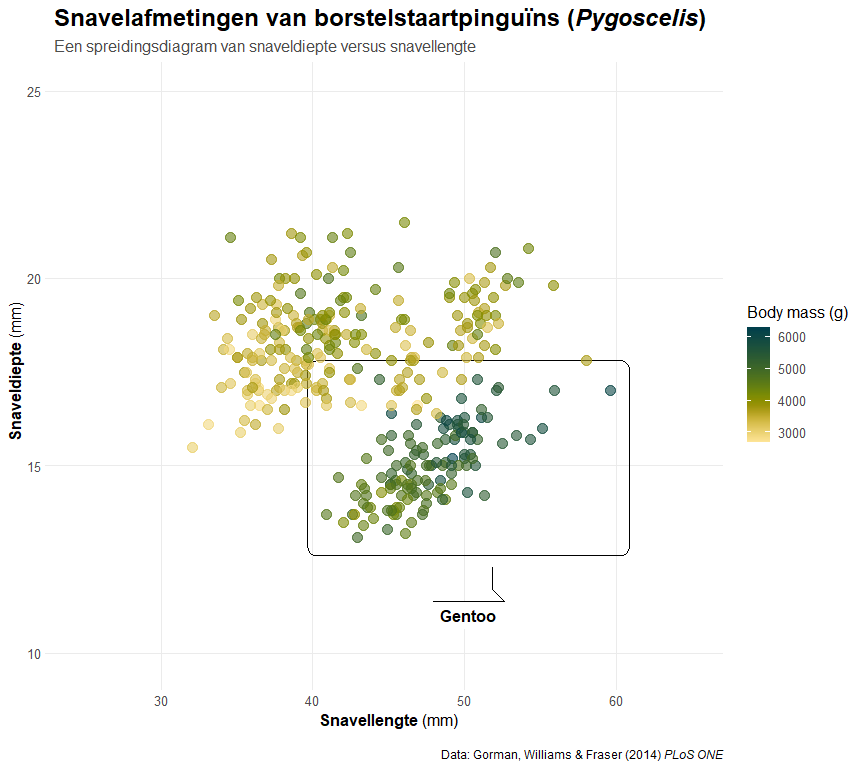

```r
ggsave("03c_ggforce_geom_mark_circle_b.pdf", width = 9, height = 8, device = cairo_pdf)

## rechthoeken
(gf +
  ggforce::geom_mark_rect(
    aes(fill = species, label = species, filter = species == 'Gentoo'),
    alpha = 0, show.legend = FALSE
  ) +
  geom_point(aes(color = body_mass_g), alpha = .6, size = 3.5)
)
```

[figure not shown]

```r
ggsave("03d_ggforce_geom_mark_rect_b.pdf", width = 9, height = 8, device = cairo_pdf)

## romp
(gf +
  ggforce::geom_mark_hull(
    aes(fill = species, label = species, filter = species == 'Gentoo'),
    alpha = 0, show.legend = FALSE
  ) +
  geom_point(aes(color = body_mass_g), alpha = .6, size = 3.5)
)
```

```r
ggsave("03e_ggforce_geom_mark_hull_b.pdf", width = 9, height = 8, device = cairo_pdf)
```

## ggplot trucks

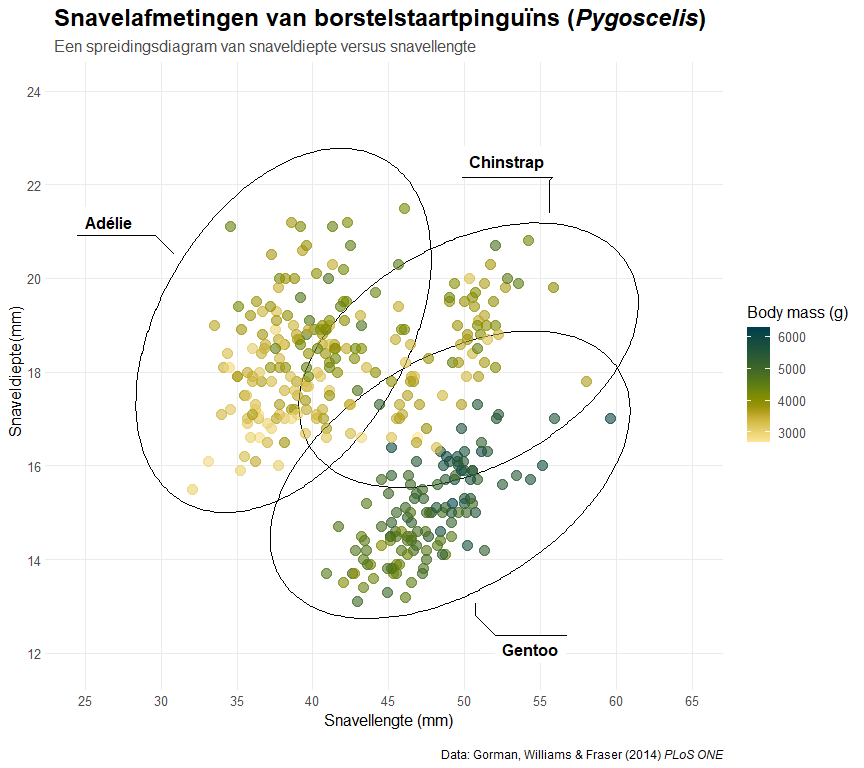

```r
(gg0 <-
  ggplot(penguins, aes(x = bill_length_mm, y = bill_depth_mm)) +
    ggforce::geom_mark_ellipse(
      aes(fill = species, label = species),
      alpha = 0, show.legend = FALSE
    ) +
    geom_point(aes(color = body_mass_g), alpha = .6, size = 3.5) +
    scale_x_continuous(breaks = seq(25, 65, by = 5), limits = c(25, 65)) +
    scale_y_continuous(breaks = seq(12, 24, by = 2), limits = c(12, 24)) +
    scico::scale_color_scico(palette = "bamako", direction = -1) +
    labs(
      title = "Snavelafmetingen van borstelstaartpinguïns (*Pygoscelis*)",
      subtitle = 'Een spreidingsdiagram van snaveldiepte versus snavellengte',
      caption = "Data: Gorman, Williams & Fraser (2014) *PLoS ONE*",
      x = "Snavellengte (mm)",
      y = "Snaveldiepte (mm)",
      color = "Body mass (g)"
    )
)
```

```r
ggsave("04_scatterplot_mod_start.pdf", width = 9, height = 8, device = cairo_pdf)
```

### Links-uitgelijnde titel

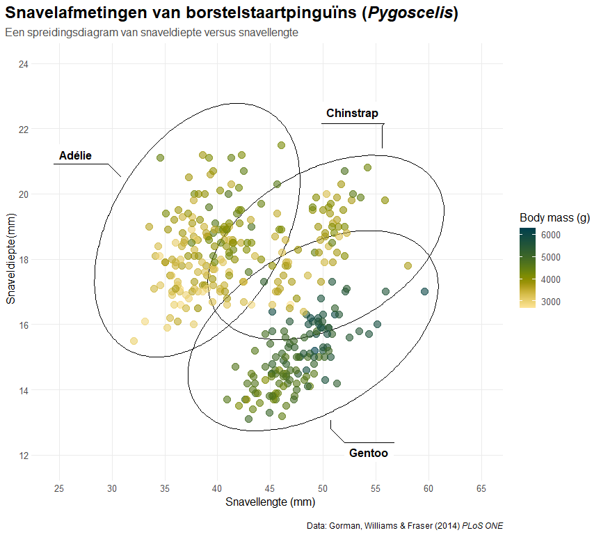

```r
(gg1 <- gg0 + theme(plot.title.position = "plot"))
```

```r
ggsave("05a_position_title.pdf", width = 9, height = 8, device = cairo_pdf)
```

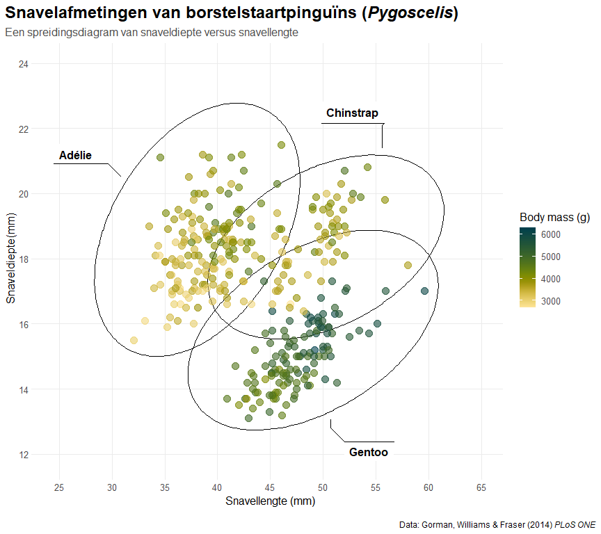

```r
(gg1b <- gg1 +  theme(plot.caption.position = "plot"))
```

```r
ggsave("05b_position_caption.pdf", width = 9, height = 8, device = cairo_pdf)
```

### Legenda ontwerp

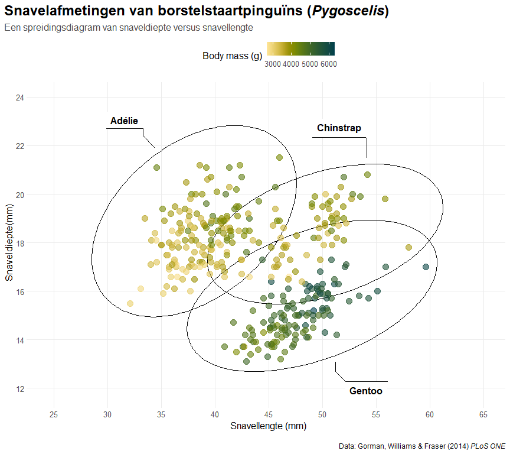

```r
(gg2 <- gg1b + theme(legend.position = "top"))
```

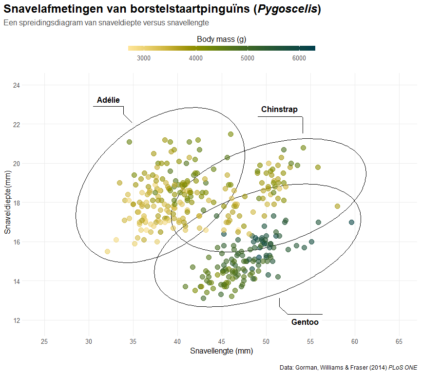

```r
ggsave("06a_legend_position.pdf", width = 9, height = 8, device = cairo_pdf)

(gg2b <- gg2 +
  guides(color = guide_colorbar(title.position = "top",
                                title.hjust = .5,
                                barwidth = unit(20, "lines"),
                                barheight = unit(.5, "lines"))))
```

```r
ggsave("06b_legend_guide.pdf", width = 9, height = 8, device = cairo_pdf)
```

### Limiet uitbreiding

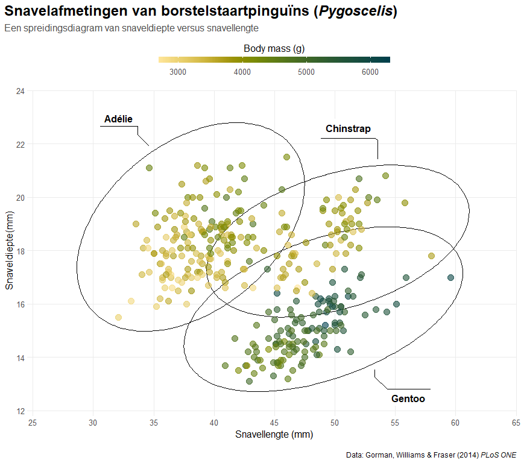

```r
(gg3 <- gg2b + coord_cartesian(expand = FALSE))
```

```r
ggsave("07_coord_expand.pdf", width = 9, height = 8, device = cairo_pdf)
```

### Gekke details: knippen

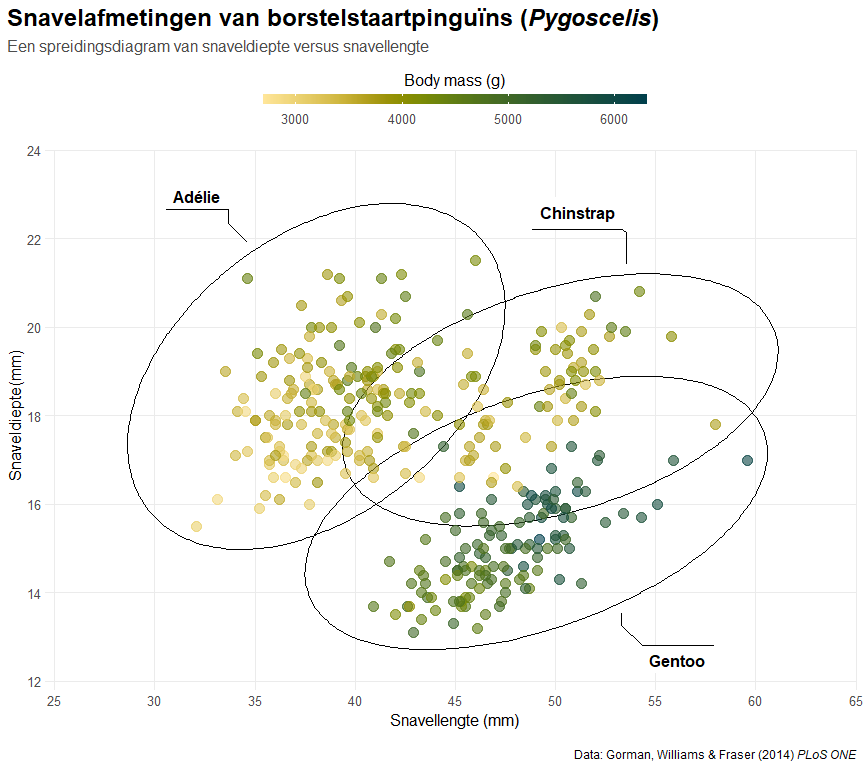

```r
(gg3b <- gg3 + coord_cartesian(expand = FALSE, clip = "off"))
```

```r
ggsave("08_coord_offclip.pdf", width = 9, height = 8, device = cairo_pdf)
```

### Witte ruimte

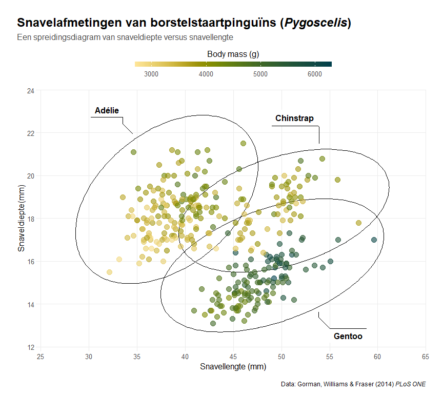

```r
(gg4 <- gg3b + theme(plot.margin = margin(t = 25, r = 25, b = 10, l = 25))) ## top, rechts, onder, links
```

```r
ggsave("09_theme_margin.pdf", width = 9, height = 8, device = cairo_pdf)
```

### Plaatjes toevoegen

[figure not shown]

```r
## lees een PNG-file van het  web
png <- magick::image_read("https://raw.githubusercontent.com/allisonhorst/palmerpenguins/master/man/figures/culmen_depth.png")
## turn image into `rasterGrob`
img <- grid::rasterGrob(png, interpolate = TRUE)

(gg5 <- gg4 +
  annotation_custom(img, ymin = 21.5, ymax = 30.5, xmin = 55, xmax = 65.5) +
    labs(caption = "Data: Gorman, Williams & Fraser (2014) *PLoS ONE* &bull; Illustration: Allison Horst"))
```

```r
ggsave("10_annotate_img.pdf", width = 9, height = 8, device = cairo_pdf)
```

## `{patchwork}`

> Het doel van `patchwork` is om het belachelijk eenvoudig te maken om afzonderlijke ggplots te combineren in dezelfde afbeelding. Als zodanig probeert het hetzelfde probleem op te lossen als `gridExtra::grid.arrange()` en `cowplot::plot_grid`, maar met behulp van een API die aanzet tot exploratie en iteratie, en schaalt naar willekeurig complexe lay-outs.

→ www.patchwork.data-imaginist.com

```r
## bereken snavelratio en statssamenvatting
df_peng_stats <-
  penguins %>%
  mutate(bill_ratio = bill_length_mm / bill_depth_mm) %>%
  filter(!is.na(bill_ratio)) %>%
  group_by(species) %>%
  mutate(
    n = n(),
    median = median(bill_ratio),
    max = max(bill_ratio)
  ) %>%
  ungroup() %>%
  mutate(species_num = as.numeric(fct_rev(species)))

## creëer een tweede grafiek chart met regenwolk plots
p2 <-
  ggplot(df_peng_stats, aes(bill_ratio, species_num, color = species)) +
  stat_summary(
    geom = "linerange",
    fun.min = function(x) -Inf,
    fun.max = function(x) median(x, na.rm = TRUE),
    linetype = "dotted",
    orientation = "y",
    size = .7
  ) +
  geom_point(
    aes(y = species_num - .15),
    shape = "|",
    size = 5,
    alpha = .33
  ) +
  ggdist::stat_halfeye(
    aes(
      y = species_num,
      color = species,
      fill = after_scale(colorspace::lighten(color, .5))
    ),
    shape = 18,
    point_size = 3,
    interval_size = 1.8,
    adjust = .5,
    .width = c(0, 1)
  ) +
  geom_text(
    aes(x = median, label = format(round(median, 2), nsmall = 2)),
    stat = "unique",
    color = "white",
    family = "Open Sans",
    fontface = "bold",
    size = 3.4,
    nudge_y = .15
  ) +
  geom_text(
    aes(x = max, label = glue::glue("n = {n}")),
    stat = "unique",
    family = "Open Sans",
    fontface = "bold",
    size = 3.5,
    hjust = 0,
    nudge_x = .01,
    nudge_y = .02
  ) +
  coord_cartesian(clip = "off", expand = FALSE) +
  scale_x_continuous(
    limits = c(1.6, 3.8),
    breaks = seq(1.6, 3.8, by = .2)
  ) +
  scale_y_continuous(
    limits = c(.55, NA),
    breaks = 1:3,
    labels = c("Gentoo", "Chinstrap", "Adélie")
  ) +
  scale_color_manual(values = c("#3d6721", "#a86826", "#006c89"), guide = "none") +
  scale_fill_manual(values = c("#3d6721", "#a86826", "#006c89"), guide = "none") +
  labs(
    x = "Snavelratio",
    y = NULL,
    subtitle = "B. Regenwolkplot met de verdeling van de snavelratio's, geschat als snavellengte gedeeld door snaveldiepte.",
    caption = "Data: Gorman, Williams & Fraser (2014) *PLoS ONE* &bull; Illustratie: Allison Horst"
  ) +
  theme(
    panel.grid.major.x = element_line(size = .35),
    panel.grid.major.y = element_blank(),
    axis.text.y = element_text(size = 13),
    axis.ticks.length = unit(0, "lines"),
    plot.title.position = 'plot',
    plot.subtitle = element_text(margin = margin(t = 5, b = 10)),
    plot.margin = margin(10, 25, 10, 25)
  )

ggsave("11_raincloud_plot.pdf", width = 9, height = 5.2, device = cairo_pdf)
```

[figure not shown]

```r
## combine both plots
(gg5 + labs(caption = NULL, subtitle = "A. Spreidingsplot van snaveldiepte tegenover snavellengte.")) / p2 +
  plot_layout(heights = c(1, .65))
```

```r
ggsave("12_patchwork_panel.pdf", width = 9, height = 13.2, device = cairo_pdf)
```

## Nog een voorbeeld van knippen

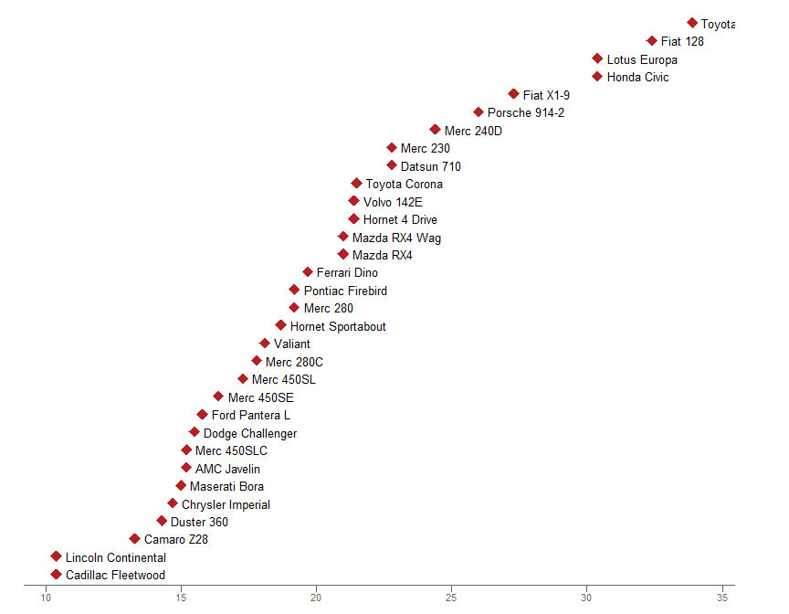

```r
## met knippen
(on <- mtcars %>%
  rownames_to_column() %>%
  ggplot(aes(mpg, fct_reorder(rowname, mpg))) +
    geom_point(size = 4, shape = "diamond", color = "firebrick") +
    geom_text(aes(label = rowname), nudge_x = .35, hjust = 0, family = "Open Sans", size = 3.3) +
    theme_void(base_size = 8, base_family = "Open Sans") +
    theme(axis.line.x = element_line(color = "grey40"),
          axis.text.x = element_text(color = "grey40"),
          axis.ticks.x = element_line(color = "grey40"),
          axis.ticks.length.x = unit(.4, "lines"),
          plot.margin = margin(10, 45, 10, 20))
)
```

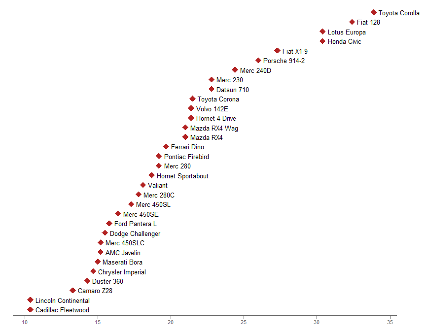

```r
ggsave("13a_clip_on.pdf", width = 9, height = 7, device = cairo_pdf)

## without clipping
on + coord_cartesian(clip = "off")
```

```r
ggsave("13b_clip_off.pdf", width = 9, height = 7, device = cairo_pdf)
```

# Bronnen

- [Slides van zijn praatjes](https://www.cedricscherer.com/slides/OutlierConf2021_ggplot-wizardry.pdf)
- [Intro to R](https://moderndive.com/) (one of many good online tutorials)
- “R for Data Science” book (open-access)
- [ggplot2 Book (open-access)](https://ggplot2-book.org/)
- [R Graph Gallery](https://www.r-graph-gallery.com/)
- [My extensive ggplot2 tutorial](https://www.cedricscherer.com/2019/08/05/a-ggplot2-tutorial-for-beautiful-plotting-in-r/)
- [Zijn “Evolution of a ggplot” blog post](https://www.cedricscherer.com/2019/05/17/the-evolution-of-a-ggplot-ep.-1/)
- [#TidyTuesday project](https://github.com/rfordatascience/tidytuesday) ([#TidyTuesday](https://twitter.com/hashtag/tidytuesday?lang=en) on Twitter)
- [My #TidyTuesday Contributions](https://github.com/Z3tt/TidyTuesday) incl. all codes
- [R4DS learning community](https://www.rfordatasci.com/) (huge Slack community for people learning R incl. a mentoring program)
- [Illustrations by Allison Horst](https://github.com/allisonhorst/stats-illustrations) (more general about data and stats + R-related)
- R Packages:
  - [ggplot2](https://ggplot2.tidyverse.org/)
  - [ggtext](https://wilkelab.org/ggtext/)
  - [ggforce](https://ggforce.data-imaginist.com/)
  - [ggdist](https://mjskay.github.io/ggdist/)
  - [ggraph](https://ggraph.data-imaginist.com/)
  - ggstream
  - ggbump
  - [gggibous](https://cran.r-project.org/web/packages/gggibbous/vignettes/gggibbous.html)
  - waffle
  - [geofacet](https://cran.r-project.org/web/packages/geofacet/vignettes/geofacet.html)
  - cartogram
  - [patchwork](https://patchwork.data-imaginist.com/)
  - [sf](https://r-spatial.github.io/sf/)

**Session Info**

```r
Sys.time()
```

```
[1] "2022-06-27 15:22:40 CEST"
```